# AllLife Credit Card Customer Segmentation

# Background:

AllLife Bank wants to focus on its credit card customer base in the next financial year. They have been advised by their marketing research team, that the penetration in the market can be improved. Based on this input, the Marketing team proposes to run personalised campaigns to target new customers as well as upsell to existing customers. Another insight from the market research was that the customers perceive the support services of the back poorly. Based on this, the Operations team wants to upgrade the service delivery model, to ensure that customers queries are resolved faster. Head of Marketing and Head of Delivery both decide to reach out to the Data Science team for help.

# Objective:

To identify different segments in the existing customer based on their spending patterns as well as past interaction with the bank.

# Key Questions:

- How many different segments of customers are there?
- How are these segments different from each other?
- What are your recommendations to the bank on how to better market to and service these customers?

# Data Description:

Data is of various customers of a bank with their credit limit, the total number of credit cards the customer has, and different channels through which customer has contacted the bank for any queries, different channels include visiting the bank, online and through a call.

Customer key - Identifier for the customer

- Average Credit Limit - Average credit limit across all the credit cards
- Total credit cards - Total number of credit cards
- Total visits bank - Total number of bank visits
- Total visits online - Total number of online visits
- Total calls made - Total number of calls made by the customer

# Steps to follow:

- Perform univariate analysis on the data to better understand the variables at your disposal and to get an idea about the no of clusters. Perform EDA, create visualizations to explore data. (10 marks)
- Properly comment on the codes, provide explanations of the steps taken in the notebook and conclude your insights from the graphs. (5 marks)
- Execute K-means clustering use elbow plot and analyse clusters using boxplot (10 marks)
- Execute hierarchical clustering (with different linkages) with the help of dendrogram and cophenetic coeff. Analyse clusters formed using boxplot (15 marks)
- Calculate average silhouette score for both methods. (5 marks)
- Compare K-means clusters with Hierarchical clusters. (5 marks)
- Analysis the clusters formed, tell us how is one cluster different from another and answer all the key questions. (10 marks)

```python
#Import libraries
import numpy as np
import pandas as pd
import matplotlib.pyplot as plt
import seaborn as sns

from sklearn.cluster import KMeans, AgglomerativeClustering
from sklearn.mixture import GaussianMixture
from matplotlib import cm
from sklearn import metrics
from sklearn.metrics import silhouette_samples, silhouette_score

from scipy.stats import zscore
from scipy.spatial.distance import cdist,pdist, squareform
from scipy.cluster.hierarchy import linkage, dendrogram, cophenet, cut_tree

from sklearn.preprocessing import StandardScaler
from sklearn.decomposition import PCA
```

```python
#Import Dataset

#Read the excel file
CCC_Segmentation_DF = pd.read_excel('Credit Card Customer Data.xlsx')
```

#### Perform univariate analysis on the data to better understand the variables at your disposal and to get an idea about the no of clusters. Perform EDA, create visualizations to explore data. (10 marks)

#### Properly comment on the codes, provide explanations of the steps taken in the notebook and conclude your insights from the graphs. (5 marks)

```python
#Univariate analysis

#Prints information about the dataset
CCC_Segmentation_DF.info()
```

```
<class 'pandas.core.frame.DataFrame'>
RangeIndex: 660 entries, 0 to 659
Data columns (total 7 columns):
 #   Column               Non-Null Count  Dtype
---  ------               --------------  -----
 0   Sl_No                660 non-null    int64
 1   Customer Key         660 non-null    int64
 2   Avg_Credit_Limit     660 non-null    int64
 3   Total_Credit_Cards   660 non-null    int64
 4   Total_visits_bank    660 non-null    int64
 5   Total_visits_online  660 non-null    int64
 6   Total_calls_made     660 non-null    int64
dtypes: int64(7)
memory usage: 36.2 KB
```

```python
#Shape of data frame
CCC_Segmentation_DF.shape
```

```
(660, 7)
```

```python
#First 15 rows
CCC_Segmentation_DF.head(15)
```

|  | Sl_No | Customer Key | Avg_Credit_Limit | Total_Credit_Cards | Total_visits_bank | Total_visits_online | Total_calls_made |
| --- | --- | --- | --- | --- | --- | --- | --- |
| 0 | 1 | 87073 | 100000 | 2 | 1 | 1 | 0 |
| 1 | 2 | 38414 | 50000 | 3 | 0 | 10 | 9 |
| 2 | 3 | 17341 | 50000 | 7 | 1 | 3 | 4 |
| 3 | 4 | 40496 | 30000 | 5 | 1 | 1 | 4 |
| 4 | 5 | 47437 | 100000 | 6 | 0 | 12 | 3 |
| 5 | 6 | 58634 | 20000 | 3 | 0 | 1 | 8 |
| 6 | 7 | 48370 | 100000 | 5 | 0 | 11 | 2 |
| 7 | 8 | 37376 | 15000 | 3 | 0 | 1 | 1 |
| 8 | 9 | 82490 | 5000 | 2 | 0 | 2 | 2 |
| 9 | 10 | 44770 | 3000 | 4 | 0 | 1 | 7 |
| 10 | 11 | 52741 | 10000 | 4 | 0 | 5 | 5 |
| 11 | 12 | 52326 | 13000 | 3 | 0 | 2 | 7 |
| 12 | 13 | 92503 | 11000 | 1 | 2 | 5 | 9 |
| 13 | 14 | 25084 | 9000 | 1 | 1 | 5 | 6 |
| 14 | 15 | 68517 | 6000 | 2 | 2 | 4 | 6 |

```python
#Last 15 rows
CCC_Segmentation_DF.tail(15)
```

|  | Sl_No | Customer Key | Avg_Credit_Limit | Total_Credit_Cards | Total_visits_bank | Total_visits_online | Total_calls_made |
| --- | --- | --- | --- | --- | --- | --- | --- |
| 645 | 646 | 48762 | 171000 | 10 | 0 | 15 | 0 |
| 646 | 647 | 58392 | 186000 | 7 | 0 | 8 | 1 |
| 647 | 648 | 79953 | 183000 | 9 | 0 | 9 | 2 |
| 648 | 649 | 13315 | 111000 | 8 | 1 | 7 | 0 |
| 649 | 650 | 30570 | 112000 | 10 | 1 | 8 | 1 |
| 650 | 651 | 78996 | 195000 | 10 | 1 | 12 | 2 |
| 651 | 652 | 78404 | 132000 | 9 | 1 | 12 | 2 |
| 652 | 653 | 28525 | 156000 | 8 | 1 | 8 | 0 |
| 653 | 654 | 51826 | 95000 | 10 | 0 | 15 | 1 |
| 654 | 655 | 65750 | 172000 | 10 | 1 | 9 | 1 |
| 655 | 656 | 51108 | 99000 | 10 | 1 | 10 | 0 |
| 656 | 657 | 60732 | 84000 | 10 | 1 | 13 | 2 |
| 657 | 658 | 53834 | 145000 | 8 | 1 | 9 | 1 |
| 658 | 659 | 80655 | 172000 | 10 | 1 | 15 | 0 |
| 659 | 660 | 80150 | 167000 | 9 | 0 | 12 | 2 |

```python
#Number of unique values in each column
CCC_Segmentation_DF.nunique()
```

```
Sl_No                  660
Customer Key           655
Avg_Credit_Limit       110
Total_Credit_Cards      10
Total_visits_bank        6
Total_visits_online     16
Total_calls_made        11
dtype: int64
```

```python
#Check Null values
CCC_Segmentation_DF.isnull().sum()
```

```
Sl_No                  0
Customer Key           0
Avg_Credit_Limit       0
Total_Credit_Cards     0
Total_visits_bank      0
Total_visits_online    0
Total_calls_made       0
dtype: int64
```

```python
#Check NA values
CCC_Segmentation_DF.isna().sum()
```

```
Sl_No                  0
Customer Key           0
Avg_Credit_Limit       0
Total_Credit_Cards     0
Total_visits_bank      0
Total_visits_online    0
Total_calls_made       0
dtype: int64
```

```python
#Check duplicate rows based on the Customer Key
CCC_Segmentation_DF[CCC_Segmentation_DF.duplicated(['Customer Key'], keep=False)].sort_values(by=['Customer Key', 'Avg_Credit_Limit'] ,ascending=False)
```

|  | Sl_No | Customer Key | Avg_Credit_Limit | Total_Credit_Cards | Total_visits_bank | Total_visits_online | Total_calls_made |
| --- | --- | --- | --- | --- | --- | --- | --- |
| 632 | 633 | 97935 | 187000 | 7 | 1 | 7 | 0 |
| 104 | 105 | 97935 | 17000 | 2 | 1 | 2 | 10 |
| 398 | 399 | 96929 | 67000 | 6 | 2 | 2 | 2 |
| 391 | 392 | 96929 | 13000 | 4 | 5 | 0 | 0 |
| 541 | 542 | 50706 | 60000 | 7 | 5 | 2 | 2 |
| 411 | 412 | 50706 | 44000 | 4 | 5 | 0 | 2 |
| 4 | 5 | 47437 | 100000 | 6 | 0 | 12 | 3 |
| 332 | 333 | 47437 | 17000 | 7 | 3 | 1 | 0 |
| 432 | 433 | 37252 | 59000 | 6 | 2 | 1 | 2 |
| 48 | 49 | 37252 | 6000 | 4 | 0 | 2 | 8 |

```python
CCC_Segmentation_DF = CCC_Segmentation_DF.drop_duplicates(subset='Customer Key', keep="last")
CCC_Segmentation_DF
```

|  | Sl_No | Customer Key | Avg_Credit_Limit | Total_Credit_Cards | Total_visits_bank | Total_visits_online | Total_calls_made |
| --- | --- | --- | --- | --- | --- | --- | --- |
| 0 | 1 | 87073 | 100000 | 2 | 1 | 1 | 0 |
| 1 | 2 | 38414 | 50000 | 3 | 0 | 10 | 9 |
| 2 | 3 | 17341 | 50000 | 7 | 1 | 3 | 4 |
| 3 | 4 | 40496 | 30000 | 5 | 1 | 1 | 4 |
| 5 | 6 | 58634 | 20000 | 3 | 0 | 1 | 8 |
| ... | ... | ... | ... | ... | ... | ... | ... |
| 655 | 656 | 51108 | 99000 | 10 | 1 | 10 | 0 |
| 656 | 657 | 60732 | 84000 | 10 | 1 | 13 | 2 |
| 657 | 658 | 53834 | 145000 | 8 | 1 | 9 | 1 |
| 658 | 659 | 80655 | 172000 | 10 | 1 | 15 | 0 |
| 659 | 660 | 80150 | 167000 | 9 | 0 | 12 | 2 |

655 rows × 7 columns

```python
#Checking after droping duplicates
CCC_Segmentation_DF.loc[CCC_Segmentation_DF['Customer Key'].isin([97935,96929,50706,47437,37252])]
```

|  | Sl_No | Customer Key | Avg_Credit_Limit | Total_Credit_Cards | Total_visits_bank | Total_visits_online | Total_calls_made |
| --- | --- | --- | --- | --- | --- | --- | --- |
| 332 | 333 | 47437 | 17000 | 7 | 3 | 1 | 0 |
| 398 | 399 | 96929 | 67000 | 6 | 2 | 2 | 2 |
| 432 | 433 | 37252 | 59000 | 6 | 2 | 1 | 2 |
| 541 | 542 | 50706 | 60000 | 7 | 5 | 2 | 2 |
| 632 | 633 | 97935 | 187000 | 7 | 1 | 7 | 0 |

```python
#Check Negative Values
print("Any negative values ?", (CCC_Segmentation_DF < 0).values.any())

print()

#Or via loop
for i in list(CCC_Segmentation_DF.columns):
    print (len(CCC_Segmentation_DF[CCC_Segmentation_DF[i] < 0]), "negative values in", i, "column")
```

```
Any negative values ? False

0 negative values in Sl_No column
0 negative values in Customer Key column
0 negative values in Avg_Credit_Limit column
0 negative values in Total_Credit_Cards column
0 negative values in Total_visits_bank column
0 negative values in Total_visits_online column
0 negative values in Total_calls_made column
```

```python
#Statistical summary
CCC_Segmentation_DF.describe().transpose()
```

|  | count | mean | std | min | 25% | 50% | 75% | max |
| --- | --- | --- | --- | --- | --- | --- | --- | --- |
| Sl_No | 655.0 | 331.552672 | 190.407385 | 1.0 | 167.5 | 331.0 | 496.5 | 660.0 |
| Customer Key | 655.0 | 55058.158779 | 25606.965469 | 11265.0 | 33623.5 | 53898.0 | 77084.5 | 99843.0 |
| Avg_Credit_Limit | 655.0 | 34563.358779 | 37648.200947 | 3000.0 | 10000.0 | 18000.0 | 48000.0 | 200000.0 |
| Total_Credit_Cards | 655.0 | 4.711450 | 2.172410 | 1.0 | 3.0 | 5.0 | 6.0 | 10.0 |
| Total_visits_bank | 655.0 | 2.404580 | 1.625385 | 0.0 | 1.0 | 2.0 | 4.0 | 5.0 |
| Total_visits_online | 655.0 | 2.601527 | 2.920192 | 0.0 | 1.0 | 2.0 | 4.0 | 15.0 |
| Total_calls_made | 655.0 | 3.575573 | 2.855867 | 0.0 | 1.0 | 3.0 | 5.0 | 10.0 |

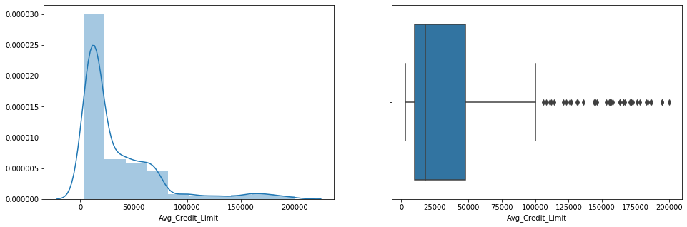

```python
#let's analyze Average Credit Limit
c, ax = plt.subplots(1, 2, figsize=(16,5))
cred_plot1 = sns.distplot(CCC_Segmentation_DF["Avg_Credit_Limit"],bins=10,  kde=True, ax= ax[0])
cred_plot2 = sns.boxplot(x='Avg_Credit_Limit',data=CCC_Segmentation_DF, orient='x', ax= ax[1])
```

```python
#From Q1 and Q3 values
Q1 = (CCC_Segmentation_DF["Avg_Credit_Limit"].describe()[['25%']]).astype(float).values[0]
Q3 = (CCC_Segmentation_DF["Avg_Credit_Limit"].describe()[['75%']]).astype(float).values[0]

outliers_lower=Q1 - 1.5*(Q3 - Q1)
outliers_upper=Q3 + 1.5*(Q3 - Q1)

print(outliers_lower)
print(outliers_upper)

#Number of outliers
#Lower
print('Number of outliers lower:',CCC_Segmentation_DF[CCC_Segmentation_DF["Avg_Credit_Limit"]<outliers_lower]['Avg_Credit_Limit'].count())
#Upper
print('Number of outliers upper:',CCC_Segmentation_DF[CCC_Segmentation_DF["Avg_Credit_Limit"]>outliers_upper]['Avg_Credit_Limit'].count())
print()
print('With the box plot analysis and calculation for Average Credit Limit we can see that it has some outliers')
```

```
-47000.0
105000.0
Number of outliers lower: 0
Number of outliers upper: 39

With the box plot analysis and calculation for Average Credit Limit we can see that it has some outliers
```

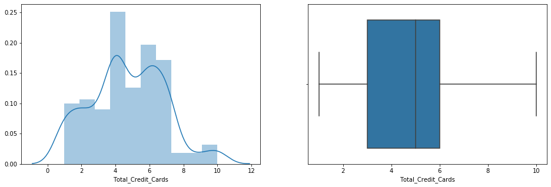

```python
#let's analyze Total credit cards
c, ax = plt.subplots(1, 2, figsize=(16,5))
cred_plot1 = sns.distplot(CCC_Segmentation_DF["Total_Credit_Cards"],bins=10,  kde=True, ax= ax[0])
cred_plot2 = sns.boxplot(x='Total_Credit_Cards',data=CCC_Segmentation_DF, orient='x', ax= ax[1])
```

```python
#From Q1 and Q3 values
Q1 = (CCC_Segmentation_DF["Total_Credit_Cards"].describe()[['25%']]).astype(float).values[0]
Q3 = (CCC_Segmentation_DF["Total_Credit_Cards"].describe()[['75%']]).astype(float).values[0]

outliers_lower=Q1 - 1.5*(Q3 - Q1)
outliers_upper=Q3 + 1.5*(Q3 - Q1)

print(outliers_lower)
print(outliers_upper)

#Number of outliers
#Lower
print('Number of outliers lower:',CCC_Segmentation_DF[CCC_Segmentation_DF["Total_Credit_Cards"]<outliers_lower]['Total_Credit_Cards'].count())
#Upper
print('Number of outliers upper:',CCC_Segmentation_DF[CCC_Segmentation_DF["Total_Credit_Cards"]>outliers_upper]['Total_Credit_Cards'].count())
print()
print('With the box plot analysis and calculation for Total credit cards we can see that it has no outliers')
```

```
-1.5
10.5
Number of outliers lower: 0
Number of outliers upper: 0

With the box plot analysis and calculation for Total credit cards we can see that it has no outliers
```

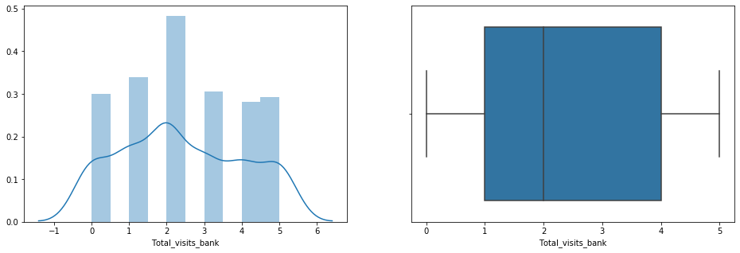

```python
#let's analyze Total visits bank
c, ax = plt.subplots(1, 2, figsize=(16,5))
cred_plot1 = sns.distplot(CCC_Segmentation_DF["Total_visits_bank"],bins=10,  kde=True, ax= ax[0])
cred_plot2 = sns.boxplot(x='Total_visits_bank',data=CCC_Segmentation_DF, orient='x', ax= ax[1])
```

```python
#From Q1 and Q3 values
Q1 = (CCC_Segmentation_DF["Total_visits_bank"].describe()[['25%']]).astype(float).values[0]
Q3 = (CCC_Segmentation_DF["Total_visits_bank"].describe()[['75%']]).astype(float).values[0]

outliers_lower=Q1 - 1.5*(Q3 - Q1)
outliers_upper=Q3 + 1.5*(Q3 - Q1)

print(outliers_lower)
print(outliers_upper)

#Number of outliers
#Lower
print('Number of outliers lower:',CCC_Segmentation_DF[CCC_Segmentation_DF["Total_visits_bank"]<outliers_lower]['Total_visits_bank'].count())
#Upper
print('Number of outliers upper:',CCC_Segmentation_DF[CCC_Segmentation_DF["Total_visits_bank"]>outliers_upper]['Total_visits_bank'].count())
print()
print('With the box plot analysis and calculation for Total visits bank we can see that it has no outliers')
```

```
-3.5
8.5
Number of outliers lower: 0
Number of outliers upper: 0

With the box plot analysis and calculation for Total visits bank we can see that it has no outliers
```

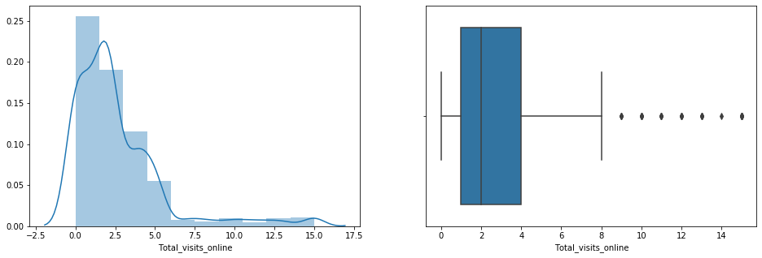

```python
#let's analyze Total visits online
c, ax = plt.subplots(1, 2, figsize=(16,5))
cred_plot1 = sns.distplot(CCC_Segmentation_DF["Total_visits_online"],bins=10,  kde=True, ax= ax[0])
cred_plot2 = sns.boxplot(x='Total_visits_online',data=CCC_Segmentation_DF, orient='x', ax= ax[1])
```

```python
#From Q1 and Q3 values
Q1 = (CCC_Segmentation_DF["Total_visits_online"].describe()[['25%']]).astype(float).values[0]
Q3 = (CCC_Segmentation_DF["Total_visits_online"].describe()[['75%']]).astype(float).values[0]

outliers_lower=Q1 - 1.5*(Q3 - Q1)
outliers_upper=Q3 + 1.5*(Q3 - Q1)

print(outliers_lower)
print(outliers_upper)

#Number of outliers
#Lower
print('Number of outliers lower:',CCC_Segmentation_DF[CCC_Segmentation_DF["Total_visits_online"]<outliers_lower]['Total_visits_online'].count())
#Upper
print('Number of outliers upper:',CCC_Segmentation_DF[CCC_Segmentation_DF["Total_visits_online"]>outliers_upper]['Total_visits_online'].count())
print()
print('With the box plot analysis and calculation for Total visits online we can see that it has some outliers')
```

```
-3.5
8.5
Number of outliers lower: 0
Number of outliers upper: 36

With the box plot analysis and calculation for Total visits online we can see that it has some outliers
```

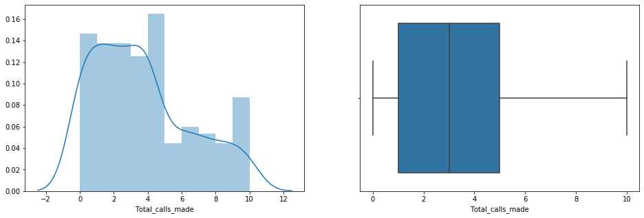

```python
#let's analyze Total calls made
c, ax = plt.subplots(1, 2, figsize=(16,5))
cred_plot1 = sns.distplot(CCC_Segmentation_DF["Total_calls_made"],bins=10,  kde=True, ax= ax[0])
cred_plot2 = sns.boxplot(x='Total_calls_made',data=CCC_Segmentation_DF, orient='x', ax= ax[1])
```

```python
#From Q1 and Q3 values
Q1 = (CCC_Segmentation_DF["Total_calls_made"].describe()[['25%']]).astype(float).values[0]
Q3 = (CCC_Segmentation_DF["Total_calls_made"].describe()[['75%']]).astype(float).values[0]

outliers_lower=Q1 - 1.5*(Q3 - Q1)
outliers_upper=Q3 + 1.5*(Q3 - Q1)

print(outliers_lower)
print(outliers_upper)

#Number of outliers
#Lower
print('Number of outliers lower:',CCC_Segmentation_DF[CCC_Segmentation_DF["Total_calls_made"]<outliers_lower]['Total_calls_made'].count())
#Upper
print('Number of outliers upper:',CCC_Segmentation_DF[CCC_Segmentation_DF["Total_calls_made"]>outliers_upper]['Total_calls_made'].count())
print()
print('With the box plot analysis and calculation for Total calls made we can see that it has no outliers')
```

```
-5.0
11.0
Number of outliers lower: 0
Number of outliers upper: 0

With the box plot analysis and calculation for Total calls made we can see that it has no outliers
```

#### Now we can drop the columns for SL No and Customer Key as they dont seem to have any categorial value for further analysis.

```python
CCC_Segmentation_DF.drop('Sl_No', axis=1, inplace=True)
```

```python
CCC_Segmentation_DF.drop('Customer Key', axis=1, inplace=True)
```

```python
CCC_Segmentation_DF
```

|  | Avg_Credit_Limit | Total_Credit_Cards | Total_visits_bank | Total_visits_online | Total_calls_made |
| --- | --- | --- | --- | --- | --- |
| 0 | 100000 | 2 | 1 | 1 | 0 |
| 1 | 50000 | 3 | 0 | 10 | 9 |
| 2 | 50000 | 7 | 1 | 3 | 4 |
| 3 | 30000 | 5 | 1 | 1 | 4 |
| 5 | 20000 | 3 | 0 | 1 | 8 |
| ... | ... | ... | ... | ... | ... |
| 655 | 99000 | 10 | 1 | 10 | 0 |
| 656 | 84000 | 10 | 1 | 13 | 2 |
| 657 | 145000 | 8 | 1 | 9 | 1 |
| 658 | 172000 | 10 | 1 | 15 | 0 |
| 659 | 167000 | 9 | 0 | 12 | 2 |

655 rows × 5 columns

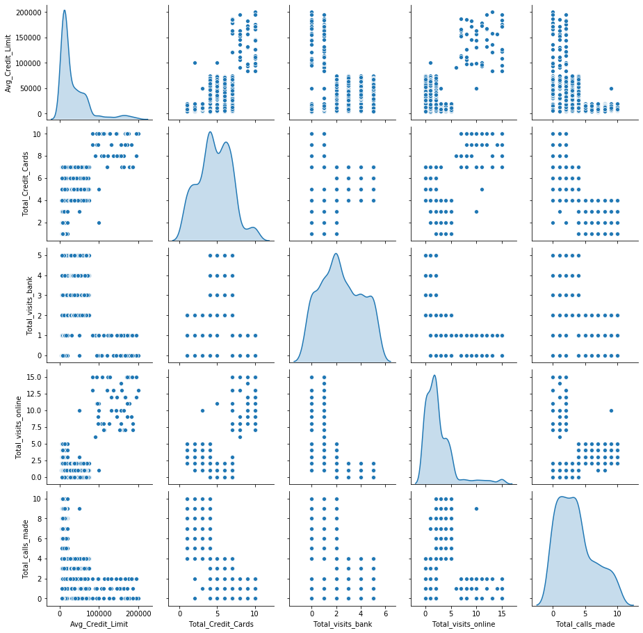

```python
#Check any relationships in a dataset using pairplot
sns.pairplot(CCC_Segmentation_DF,diag_kind='kde')
```

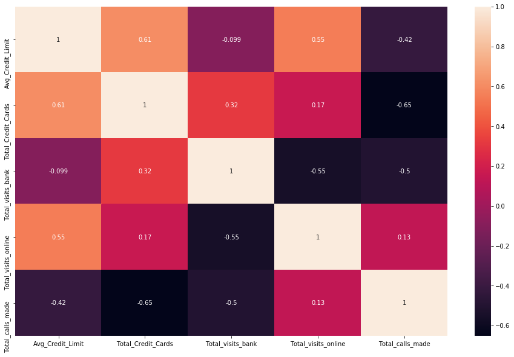

```python
#Checking the correlation coefficients to see which variables are highly correlated
plt.figure(figsize = (16, 10))
sns.heatmap(CCC_Segmentation_DF.corr(), annot = True)
plt.show()
```

#### Execute K-means clustering use elbow plot and analyse clusters using boxplot (10 marks)

```python
##Scale the data
ZScore_DF = CCC_Segmentation_DF.apply(zscore)
ZScore_DF.head()
```

|  | Avg_Credit_Limit | Total_Credit_Cards | Total_visits_bank | Total_visits_online | Total_calls_made |
| --- | --- | --- | --- | --- | --- |
| 0 | 1.739436 | -1.249084 | -0.864813 | -0.548851 | -1.252966 |
| 1 | 0.410337 | -0.788414 | -1.480522 | 2.535493 | 1.900849 |
| 2 | 0.410337 | 1.054266 | -0.864813 | 0.136559 | 0.148730 |
| 3 | -0.121303 | 0.132926 | -0.864813 | -0.548851 | 0.148730 |
| 5 | -0.387123 | -0.788414 | -1.480522 | -0.548851 | 1.550425 |

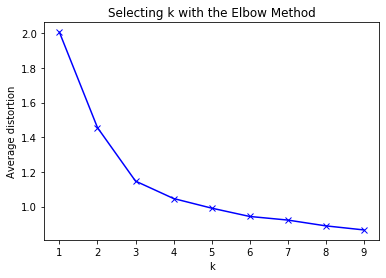

```python
clusters=range(1,10)
meanDistortions=[]

for k in clusters:
    model=KMeans(n_clusters=k)
    model.fit(ZScore_DF)
    prediction=model.predict(ZScore_DF)
    meanDistortions.append(sum(np.min(cdist(ZScore_DF, model.cluster_centers_, 'euclidean'), axis=1)) / ZScore_DF.shape[0])

plt.plot(clusters, meanDistortions, 'bx-')
plt.xlabel('k')
plt.ylabel('Average distortion')
plt.title('Selecting k with the Elbow Method')
```

#### As shown above graph, the elbow method K value of 3 seems to be the right point where the graph deflects and will be used for further analysis

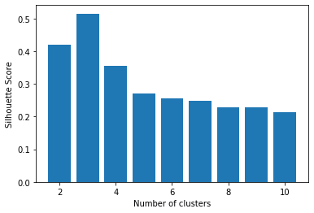

```python
silhouette_scores = []

for n_cluster in range(2, 11):
    silhouette_scores.append(
        silhouette_score(ZScore_DF, KMeans(n_clusters = n_cluster).fit_predict(ZScore_DF)))

# Plotting a bar graph to compare the results
k = [2, 3, 4, 5, 6,7,8,9,10]
plt.bar(k, silhouette_scores)
plt.xlabel('Number of clusters', fontsize = 10)
plt.ylabel('Silhouette Score', fontsize = 10)
plt.show()
```

#### As shown above graph, the silhouette score at cluster K=3 is the highest.

```python
final_model=KMeans(3)
final_model.fit(ZScore_DF)
prediction=final_model.predict(ZScore_DF)

#Append the prediction
CCC_Segmentation_DF["K_Means_Cluster"] = prediction
ZScore_DF["K_Means_Cluster"] = prediction
print("K_Means_Cluster Assigned : \n")
CCC_Segmentation_DF.head()
```

```
K_Means_Cluster Assigned :
```

|  | Avg_Credit_Limit | Total_Credit_Cards | Total_visits_bank | Total_visits_online | Total_calls_made | K_Means_Cluster |
| --- | --- | --- | --- | --- | --- | --- |
| 0 | 100000 | 2 | 1 | 1 | 0 | 1 |
| 1 | 50000 | 3 | 0 | 10 | 9 | 2 |
| 2 | 50000 | 7 | 1 | 3 | 4 | 1 |
| 3 | 30000 | 5 | 1 | 1 | 4 | 1 |
| 5 | 20000 | 3 | 0 | 1 | 8 | 2 |

```python
Cluster_DF = CCC_Segmentation_DF.groupby(['K_Means_Cluster'])
Cluster_DF.mean()
```

| K_Means_Cluster | Avg_Credit_Limit | Total_Credit_Cards | Total_visits_bank | Total_visits_online | Total_calls_made |
| --- | --- | --- | --- | --- | --- |
| 0 | 141877.551020 | 8.795918 | 0.612245 | 10.877551 | 1.040816 |
| 1 | 33809.895833 | 5.523438 | 3.481771 | 0.986979 | 2.005208 |
| 2 | 12180.180180 | 2.405405 | 0.936937 | 3.567568 | 6.851351 |

#### Analyzing the clusters using boxplots

```
array([[<matplotlib.axes._subplots.AxesSubplot object at 0x0000023371F4B348>,
      dtype=object)
```

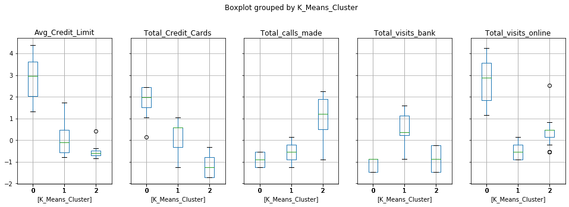

```python
ZScore_DF.boxplot(by='K_Means_Cluster', layout = (2,5),figsize=(16,10))
```

#### Execute hierarchical clustering (with different linkages) with the help of dendrogram and cophenetic coeff. Analyse clusters formed using boxplot (15 marks)

```python
Hcluster_DF = ZScore_DF.drop('K_Means_Cluster',1)
Hcluster_DF.head()
```

|  | Avg_Credit_Limit | Total_Credit_Cards | Total_visits_bank | Total_visits_online | Total_calls_made |
| --- | --- | --- | --- | --- | --- |
| 0 | 1.739436 | -1.249084 | -0.864813 | -0.548851 | -1.252966 |
| 1 | 0.410337 | -0.788414 | -1.480522 | 2.535493 | 1.900849 |
| 2 | 0.410337 | 1.054266 | -0.864813 | 0.136559 | 0.148730 |
| 3 | -0.121303 | 0.132926 | -0.864813 | -0.548851 | 0.148730 |
| 5 | -0.387123 | -0.788414 | -1.480522 | -0.548851 | 1.550425 |

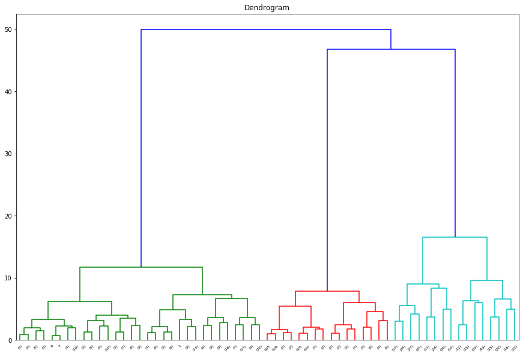

```python
#Plotting the Dendrogram
plt.figure(figsize=(15,10))
Merge_DF = linkage(Hcluster_DF, method='ward')
dendrogram(Merge_DF, leaf_rotation = 45, p=5,truncate_mode='level')
plt.title('Dendrogram')
plt.show()
```